# Trabalho Final - R para Iniciantes

Maurílio Bonora Júnior

15/05/2019

## Introdução

Sempre que vamos escrever um projeto ou relatório, somos bombardeados por um gigantesca base de dados com artigos de relevância variável sobre o determinado assunto. Organizar e escolher os melhores artigos dentre essa imensidão de referências é uma dura tarefa, que muitas vezes pode demandar um tempo que muitos pesquisadores não têm. Contudo, com o advento do R e seus diversos pacotes, entre eles o “Bibliometrix”, essa tarefa de comparar artigos para escolher os melhores se tornou muito mais fácil. Para exemplificar isso, foram escolhidos dois termos para se começar a busca de arquivos em base de dados (Scopus). Tais termos foram: “TCR” e “Signalling”. A escolha dos termos foi feito baseado na experiência do autor desse trabalho, vide que a área de pesquisa desse se dá em tal área (Imunologia celular e molecular). Abaixo segue todo o procedimento com os códigos e gráficos possíveis de se fazer com o pacote “Bibliometrix”.

## Requerimentos

Para a realização do trabalho, foram necessários alguns programas e pacotes, dentre eles:

- O próprio R: garante toda a linguagem R para se trabalhar;
- RStudio: um software com uma interface mais elegante e amigável ao usuário para ele conseguir trabalho;
- Git: um sistema de controle de versão distribuído. Utilizado juntamente do Rmarkdown para se fazer o upload direto do trabalho para um repositório em nuvem (Github);
- MikTex: programa necessário para a conversão do Script do Rmarkdown para PDf;
- Pacote “Rmarkdown”: converte scripts do R (mais especificamente do Rmarkdown) em uma variedade de formatos incluindo HTML, MS Word, PDF e Beamer. Além disso, o Rmarkdown consegue compilar os scripts em especíes de “livros” onde é possível colocar comentários, códigos fontes e a saída (resultado) do código do script;
- Pacote “Bibliometrix”: garante um conjunto de ferramentas muito útil para análises na área de cientometria e bibliometria;
- Um arquivo Scopus.bib: arquivo baixado da base de dados Scopus com todas as informações de artigos escolhidos a partir das palavras-chaves selecionado.

## Desenvolvimento

#### Carregamento e Conversão dos Dados

Após a instalação do R, RStudio, Miktex e Git (lembrando que é necessário a criação de um diretório com o nome do trabalho no Git), é necessário fazer o download dos pacotes “Rmarkdown” e “Bibliometrix”.

Em seguida é necessário carregar o pacote “Bibliometrix”:

```r
library(bibliometrix)
```

Já com o arquivo scopus.bib dentro da sua pasta de trabalho está na hora de começar a preparar os dados para as análises. A primeira função que será utilizada é “read.Files”, que converte todos os arquivos de texto de scopus.bib em um grande vetor de caracteres que chamaremos de D.

```r
D<-readFiles("scopus.bib")
```

Esse grande objeto D pode então ser convertido em um DataFrame a partir da função “convert2df”.

```r
M <- convert2df(D, dbsource = "scopus", format = "bibtex")
```

```
##
## Converting your scopus collection into a bibliographic dataframe
##
## Articles extracted   100
## Articles extracted   200
## Articles extracted   300
## Articles extracted   400
## Articles extracted   500
## Articles extracted   511
## Done!
##
##
## Generating affiliation field tag AU_UN from C1:  Done!
```

#### Análise Bibliométrica

O primeiro passo para fazer uma análise descritiva desse Data Frame é utilizara função “biblioAnalysis”, que irá calcular as principais medidas bibliométricas de toda nossa base de dados.

```r
results<-biblioAnalysis(M, sep = ";")
```

Tal função retorna um objeto da classe bibliometrix (introduzida com o pacote homônimo), que contem os seguintes componentes como o número total de artigos, primeiro autor de cada manuscrito, número de vezes que cada manustrico foi citado, entre outros. Para mais informações use a função:

```r
help("biblioAnalysis")
```

```
## starting httpd help server ... done
```

Contudo, o objeto “results” que obtemos ainda é muito grande e complicado de se ler, sendo muito laborioso obter informações gerais a partir dali. Para isso, usa-se a função “summary” para se obter os principais resultados da nossa análise bibliométrica. Essa função aceita ainda dois argumentos adicionais: “k” é um valor de formatação que indica quantas linhas de cada tabela serão mostradas, enquanto “pause” é um valor lógico usado para permitir ou não a pausa na rolagem da tela.

```r
summary(results, k =10, pause = FALSE)
```

```
##
##
## Main Information about data
##
##  Documents                             511
##  Sources (Journals, Books, etc.)       127
##  Keywords Plus (ID)                    3213
##  Author's Keywords (DE)                609
##  Period                                1989 - 2019
##  Average citations per documents       38.77
##
##  Authors                               2560
##  Author Appearances                    3047
##  Authors of single-authored documents  16
##  Authors of multi-authored documents   2544
##  Single-authored documents             17
##
##  Documents per Author                  0.2
##  Authors per Document                  5.01
##  Co-Authors per Documents              5.96
##  Collaboration Index                   5.15
##
##  Document types
##  ARTICLE               445
##  BOOK CHAPTER          6
##  CONFERENCE PAPER      5
##  EDITORIAL             2
##  ERRATUM               4
##  NOTE                  5
##  REVIEW                40
##  SHORT SURVEY          4
##
##
## Annual Scientific Production
##
##  Year    Articles
##     1989        1
##     1990        1
##     1991        1
##     1992        1
```

[output cut: 109 more lines]

```
##
##
## Most Relevant Keywords
##
##    Author Keywords (DE)      Articles Keywords-Plus (ID)     Articles
## 1        SIGNAL TRANSDUCTION       28  SIGNAL TRANSDUCTION        788
## 2        TCR                       27  MICE                       477
## 3        TCR SIGNALING             18  RECEPTORS                  420
## 4        T CELL RECEPTOR           17  ARTICLE                    418
## 5        T LYMPHOCYTES             16  T LYMPHOCYTE RECEPTOR      402
## 6        T CELL                    15  ANTIGEN                    400
## 7        T CELL ACTIVATION         15  T CELL                     397
## 8        T CELLS                   14  PRIORITY JOURNAL           380
## 9        SIGNALING                 11  HUMAN                      315
## 10       T CELL SIGNALING          10  MOUSE                      314
```

A partir daí obtemos uma série de resultados interessantes, desde as principais informações dos nossos dados - como nº de documentos, média de citações por artigos, nº de autores, nº de artigos com autores únicos - até informações mais curiosas como a produção de artios por ano desde o primeiro que foi publicado, autores mais produtivos, países com maiores nº de citações, principais fontes de artigos, entre diversas outras. Por fim, a partir dessas mesmos informações básicas obtidas, é possível montar gráficos que nos dão uma ideia bem mais visual da relação entre nossos dados, usando a função “plot”.

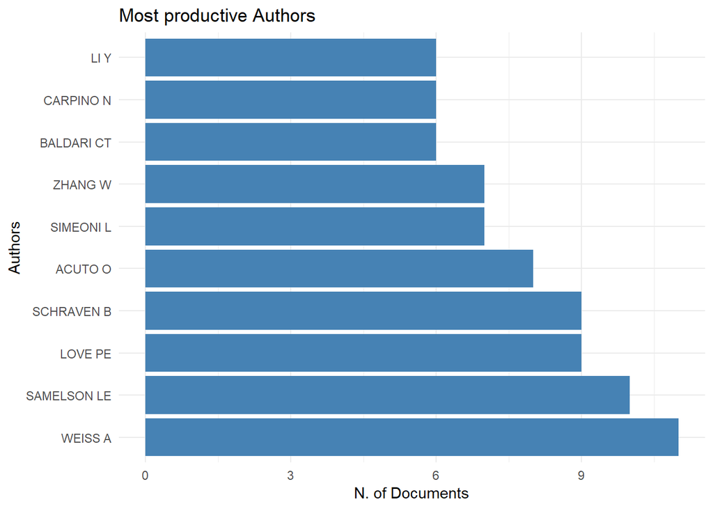

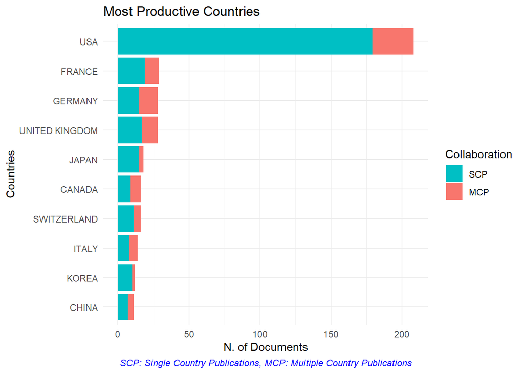

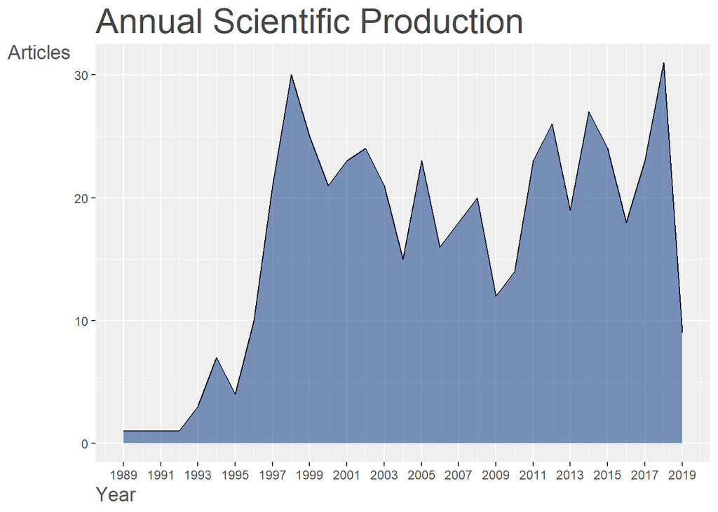

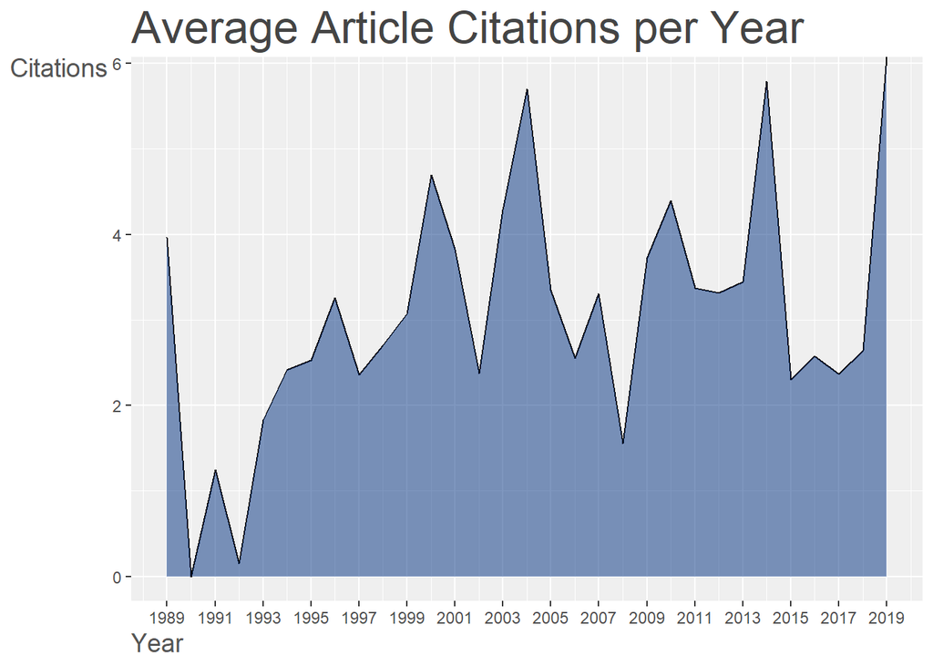

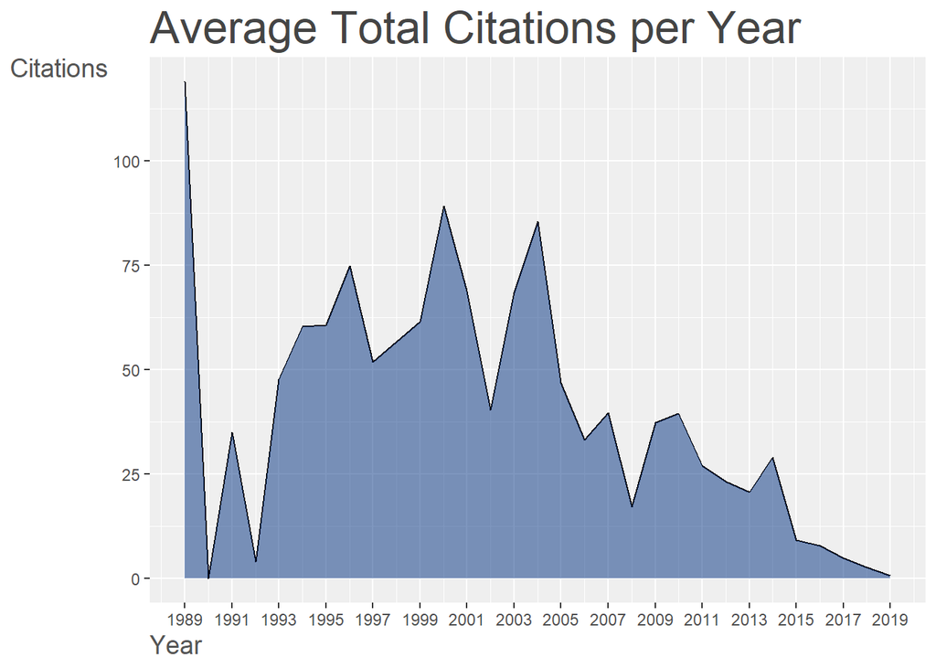

```r
plot(x=results, k=10, pause=FALSE)
```

#### Análise de Referências Citadas

É possível produzir uma tabela mostrando as referências mais citadas dos autores mais citados, utilizando-se a função “citations”. Para se obter os artigos mais citadas, usa-se:

```r
CR <- citations(M, field = "article", sep = ";")
cbind(CR$Cited[1:10])
```

```
##                                                                                                                                                                                                                                          [,1]
## ZHANG, W., SLOAN-LANCASTER, J., KITCHEN, J., TRIBLE, R.P., SAMELSON, L.E., LAT: THE ZAP-70 TYROSINE KINASE SUBSTRATE THAT LINKS T CELL RECEPTOR TO CELLULAR ACTIVATION (1998) CELL, 92, PP. 83-92                                          24
## SMITH-GARVIN, J.E., KORETZKY, G.A., JORDAN, M.S., T CELL ACTIVATION (2009) ANNU. REV. IMMUNOL., 27, PP. 591-619                                                                                                                            21
## WEISS, A., LITTMAN, D.R., SIGNAL TRANSDUCTION BY LYMPHOCYTE ANTIGEN RECEPTORS (1994) CELL, 76, PP. 263-274                                                                                                                                 20
## WEISS, A., LITTMAN, D.R., SIGNAL TRANSDUCTION BY LYMPHOCYTE ANTIGEN RECEPTORS (1994) CELL, 76, P. 263                                                                                                                                      16
## XAVIER, R., BRENNAN, T., LI, Q., MCCORMACK, C., SEED, B., MEMBRANE COMPARTMENTATION IS REQUIRED FOR EFFICIENT T CELL ACTIVATION (1998) IMMUNITY, 8, PP. 723-732                                                                            13
## VARMA, R., CAMPI, G., YOKOSUKA, T., SAITO, T., DUSTIN, M.L., T CELL RECEPTOR-PROXIMAL SIGNALS ARE SUSTAINED IN PERIPHERAL MICROCLUSTERS AND TERMINATED IN THE CENTRAL SUPRAMOLECULAR ACTIVATION CLUSTER (2006) IMMUNITY, 25, PP. 117-127   12
## VIOLA, A., SCHROEDER, S., SAKAKIBARA, Y., LANZAVECCHIA, A., T LYMPHOCYTE COSTIMULATION MEDIATED BY REORGANIZATION OF MEMBRANE MICRODOMAINS (1999) SCIENCE, 283, PP. 680-682                                                                12
## WANGE, R.L., SAMELSON, L.E., COMPLEX COMPLEXES: SIGNALING AT THE TCR (1996) IMMUNITY, 5, P. 197                                                                                                                                            11
## ZHANG, W., TRIBLE, R.P., SAMELSON, L.E., LAT PALMITOYLATION: ITS ESSENTIAL ROLE IN MEMBRANE MICRODOMAIN TARGETING AND TYROSINE PHOSPHORYLATION DURING T CELL ACTIVATION (1998) IMMUNITY, 9, PP. 239-246                                    11
## CANTRELL, D., T CELL ANTIGEN RECEPTOR SIGNAL TRANSDUCTION PATHWAYS (1996) ANNU. REV. IMMUNOL., 14, P. 259                                                                                                                                  10
```

Enquanto que para se obter os autores mais citados, usa-se:

```r
CR<- citations(M, field = "author", sep = ";")
cbind(CR$Cited[1:10])
```

```
##               [,1]
## WEISS A        669
## SAMELSON L E   403
## KORETZKY G A   268
## DAVIS M M      244
## VON BOEHMER H  240
## CHAN A C       219
## ZHANG W        216
## GERMAIN R N    192
## ALLEN P M      185
## DUSTIN M L     177
```

Por fim, é possível montar ainda uma tabela onde mostra-se os autores mais citados “localmente”, isto é, dentre a base de dados que temos, quais foram os autores mais citados entre os outros autores dessa base. Para isso, utilizamos a função “LocalCitations”. Utilizaremos as mesmas funções auxiliares usadas anteriormente para ver os 10 principais autores e principais artigos citados local e respectivamente:

```r
CR <- localCitations(M, sep = ";")
```

```
## Articles analysed   100
## Articles analysed   200
## Articles analysed   300
## Articles analysed   400
## Articles analysed   462
```

```r
CR$Authors[1:10,]
```

|  | Author | LocalCitations |
| --- | --- | --- |
| 11 | ACUTO O | 30 |
| 1776 | SAMELSON LE | 28 |
| 1389 | MICHEL F | 21 |
| 2213 | WANGE RL | 21 |
| 1255 | LOVE PE | 20 |
| 2121 | TUOSTO L | 16 |
| 88 | ATTAL BONNEFOY G | 14 |
| 1302 | MANGINO G | 14 |
| 2227 | WEISS A | 14 |
| 1896 | SHORES EW | 13 |

```r
CR$Papers[1:10,]
```

|  | Paper | DOI | Year | LCS | GCS |
| --- | --- | --- | --- | --- | --- |
| 24 | WANGE RL, 1996, IMMUNITY | 10.1016/S1074-7613(00)80315-5 | 1996 | 19 | 443 |
| 58 | TUOSTO L, 1998, EUR J IMMUNOL | 10.1002/(SICI)1521-4141(199807)28:073.0.CO;2-Q | 1998 | 9 | 85 |
| 124 | AZZAM HS, 2001, J IMMUNOL | 10.4049/JIMMUNOL.166.9.5464 | 2001 | 9 | 180 |
| 191 | CIOFANI M, 2004, J IMMUNOL | 10.4049/JIMMUNOL.172.9.5230 | 2004 | 9 | 183 |
| 99 | MICHEL F, 2000, J IMMUNOL | 10.4049/JIMMUNOL.165.7.3820 | 2000 | 7 | 73 |
| 132 | MICHEL F, 2001, IMMUNITY | 10.1016/S1074-7613(01)00244-8 | 2001 | 7 | 128 |
| 133 | RAAB M, 2001, IMMUNITY | 10.1016/S1074-7613(01)00248-5 | 2001 | 7 | 84 |
| 362 | GUY CS, 2013, NAT IMMUNOL | 10.1038/NI.2538 | 2013 | 7 | 97 |
| 139 | KOSUGI A, 2001, IMMUNITY | 10.1016/S1074-7613(01)00146-7 | 2001 | 6 | 85 |
| 195 | CARPINO N, 2004, IMMUNITY | 10.1016/S1074-7613(03)00351-0 | 2004 | 6 | 100 |

#### Ranking de Dominância de Autores

O fator de dominância é uma taxa que indica a fração de artigos com múltiplos autores em que um pesquisador aparece como primeiro autor. A função “dominance” calcula o ranking da dominância entre os autores.

```r
DF <- dominance(results, k = 10)
DF
```

|  | Author | Dominance Factor | Tot Articles | Single-Authored | Multi-Authored | First-Authored | Rank by Articles | Rank by DF |
| --- | --- | --- | --- | --- | --- | --- | --- | --- |
| 1 | HARDER T | 0.6666667 | 4 | 1 | 3 | 2 | 1 | 1 |
| 2 | MICHEL F | 0.5000000 | 6 | 0 | 6 | 3 | 5 | 2 |
| 3 | CARPINO N | 0.3333333 | 6 | 0 | 6 | 2 | 5 | 3 |
| 4 | HOUTMAN JCD | 0.2500000 | 4 | 0 | 4 | 1 | 1 | 4 |
| 5 | LEITENBERG D | 0.2500000 | 4 | 0 | 4 | 1 | 1 | 4 |
| 6 | VAN OERS NSC | 0.2000000 | 5 | 0 | 5 | 1 | 4 | 6 |
| 7 | LI Y | 0.1666667 | 6 | 0 | 6 | 1 | 5 | 7 |
| 8 | ZHANG W | 0.1428571 | 7 | 0 | 7 | 1 | 8 | 8 |
| 9 | ACUTO O | 0.1250000 | 8 | 0 | 8 | 1 | 9 | 9 |
| 10 | LOVE PE | 0.1111111 | 9 | 0 | 9 | 1 | 10 | 10 |

#### O índice-h dos autores

O índice-h é uma métrica que mede ambas produtividade e impacto de citação das publicações de cientistas. Esse índice é baseado no conjunto de artigos mais citados do autor em específico e no número de citações que esses artigos receberam em outras publicações. A função “Hindex” calcula o índice-h de autores ou de fontes e suas variantes (índice-g e índice-m) em uma conjunto de dados bibliográficos. Para calcular o índice-h dos 10 autores mais produtivos dessa coleção em específico, utilizaremos os seguintes códigos:

```r
authors=gsub(","," ",names(results$Authors)[1:10])
indices <- Hindex(M, field = "author", elements=authors, sep = ";", years = 50)
indices$H
```

[output not shown]

#### Produtividade dos principais autores no decorrer do tempo

A função “AuthorProdOverTime” facilmente consegue nos dar um gráfico mostrando a produção dos 10 primeiros autores (em termos de número de publicações e número de citações totais por ano) no decorrer do tempo.

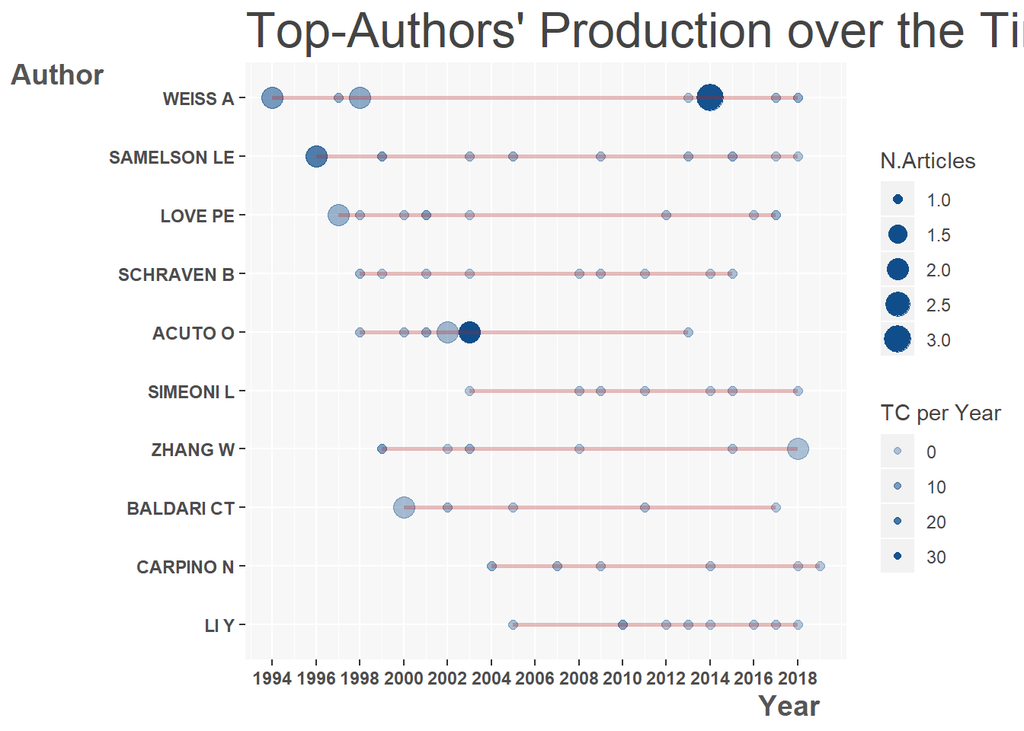

```r
topAU <- authorProdOverTime(M, k = 10, graph = TRUE)
```

#### Estimativa do coeficiente da regra de Lotka

A regra de Lotka descreve a frequência de publicação dos autores de um determinado campo como uma lei do quadrado inversa, onde o número de autores publicando um determinado número de artigos é uma taxa fixa para o número de autores publicando um artigo único. Essa suposição implica que o coeficiente beta teórico da regra de Lotka é igual a 2. A função “lotka” estima os coeficientes dessa regra de Lotka. Usando tal função é possível estimar por exemplo o coeficiente beta, dito anteriormente, de nossa coleção bibliográfica e acessar - a partir de um teste estatístico - a similaridade da distribuição empírica com uma teórica.

- Distribuição empírica da produtividade dos autores:

```r
L <- lotka(results)
L$AuthorProd
```

| N.Articles | N.Authors | Freq |
| --- | --- | --- |
| 1 | 2248 | 0.878125000 |
| 2 | 224 | 0.087500000 |
| 3 | 48 | 0.018750000 |
| 4 | 23 | 0.008984375 |
| 5 | 6 | 0.002343750 |
| 6 | 4 | 0.001562500 |
| 7 | 2 | 0.000781250 |
| 8 | 1 | 0.000390625 |
| 9 | 2 | 0.000781250 |
| 10 | 1 | 0.000390625 |

[output cut: 1 more lines]

- Coeficiente beta estimado:

```r
L$Beta
```

```
## [1] 3.370245
```

- Constante:

```r
L$C
```

```
## [1] 0.7867831
```

- Qualidade de ajuste:

```r
L$R2
```

```
## [1] 0.980799
```

- Valor p dos dois testes K-S da amostra

```r
L$p.value
```

```
## [1] 0.02325117
```

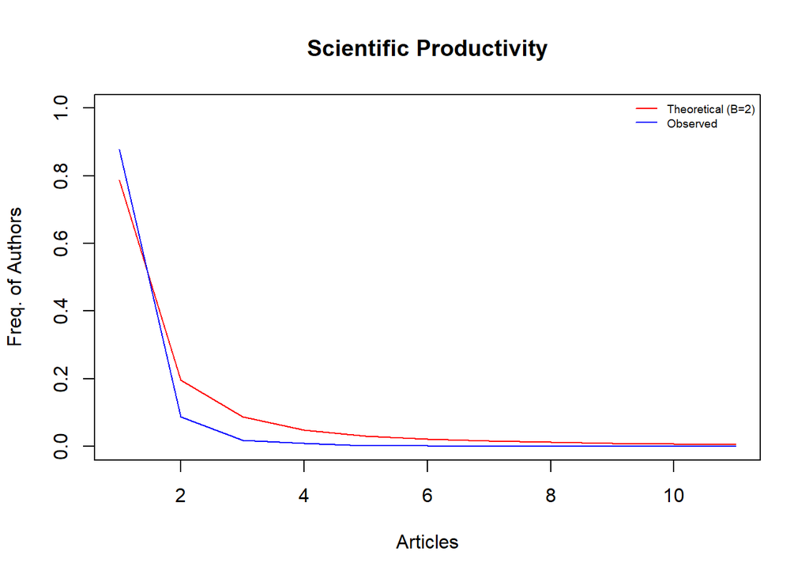

```r
Observed=L$AuthorProd[,3]
Theoretical=10^(log10(L$C)-2*log10(L$AuthorProd[,1]))
plot(L$AuthorProd[,1],Theoretical,type="l",col="red",ylim=c(0, 1), xlab="Articles",ylab="Freq. of Authors",main="Scientific Productivity")
lines(L$AuthorProd[,1],Observed,col="blue")
legend(x="topright",c("Theoretical (B=2)","Observed"),col=c("red","blue"),lty = c(1,1,1),cex=0.6,bty="n")
```

#### Matrizes de Redes Bibliográficas

As características de um artigo científico estão todas conectadas entre si a partir do próprio artigo, via os próprios autores ao revista ou periódico publicado, as palavras chaves com a data de publicação, etc. As conexões entre diferentes características geram redes bipartidas que podem ser representadas na forma de matrizes retangulares (artigo x qualquer que seja a característica). Além disso, publicação científicas normalmente possuem referências a outros artigos. Isso acaba por gerar uma nova rede, chamada rede de acoplamento ou de co-citação. Essas redes são utilizadas para analizar e capturar o real significado de certas propriedades em sistemas de pesquisas e, em particular, determinar a influência de algumas unidades bibliométricas como revistas e periódicos.

#### Redes bipartidas

A função “cocMatrix” é usada para computar uma rede bipartida selecionando um dos atributos dos dados, por exemplo, uma rede Artigo x Fonte da Publicação:

```r
A <- cocMatrix(M, Field = "SO", sep = ";")
sort(Matrix::colSums(A), decreasing = TRUE)[1:5]
```

```
##            JOURNAL OF IMMUNOLOGY   EUROPEAN JOURNAL OF IMMUNOLOGY                NATURE IMMUNOLOGY
##                              158                               32                               26
## JOURNAL OF EXPERIMENTAL MEDICINE                            BLOOD
##                               16                               16
```

Seguindo a mesma lógica, é possível fazer outros tipos de redes bipartidárias:

- Rede de citações

```r
A <- cocMatrix(M, Field = "CR", sep = ".  ")
sort(Matrix::colSums(A), decreasing = TRUE)[1:5]
```

```
##        WEISS A. LITTMAN D.R. SIGNAL TRANSDUCTION BY LYMPHOCYTE ANTIGEN RECEPTORS (1994)
##                                                                                      16
##                    SMITH-GARVIN J.E. KORETZKY G.A. JORDAN M.S. T CELL ACTIVATION (2009)
##                                                                                       6
##    VON BOEHMER H. FEHLING H.J. STRUCTURE AND FUNCTION OF THE PRE-T CELL RECEPTOR (1997)
##                                                                                       6
##                     ROBEY E. FOWLKES B.J. SELECTIVE EVENTS IN T CELL DEVELOPMENT (1994)
##                                                                                       5
## STARR T.K. JAMESON S.C. HOGQUIST K.A. POSITIVE AND NEGATIVE SELECTION OF T CELLS (2003)
##                                                                                       4
```

- Rede de Autores:

```r
A <- cocMatrix(M, Field = "AU", sep = ";")
sort(Matrix::colSums(A), decreasing = TRUE)[1:5]
```

```
##     WEISS A SAMELSON LE     LOVE PE  SCHRAVEN B     ACUTO O
##          11          10           9           9           8
```

- Rede de palavras-chaves (dos autores):

```r
A <- cocMatrix(M, Field = "DE", sep = ";")
sort(Matrix::colSums(A), decreasing = TRUE)[1:5]
```

```
## SIGNAL TRANSDUCTION                 TCR       TCR SIGNALING              T CELL     T CELL RECEPTOR
##                  28                  26                  18                  15                  14
```

#### Redes de acoplamento

De acordo com Kessler (1993), podemos dizer que dois artigos estão acoplados bibliográficamente se pelo menos uma das fontes citadas aparece nas referências bibliográficas de ambos os artigos. A função “biblioNetwork” calcula, a partir de um data frame bibliográfico, as redes de acoplamento mais comumente usadas: de autores, de fontes e países.

Artigos com poucas referências, consequentemente, tendem a ficar menos bibliograficamente acoplados (mais distantes um do outro em um gráfico), se a “força” de acoplamento é medida simplesmente pelo número de referências que aquele artigo tem em comum com outros. Isso nos sugere que pode ser melhor utilizar uma medida relativa (e não absoluta) para o acoplamento bibliográfico.

Através da função “normalizeSimilarity”, é possível se calcular a força de associação, inclusão e a similaridade de Jaccard ou Salton entre os vértices de uma rede.

Como exemplo, segue uma rede de acomplamento para os autores de nossos dados:

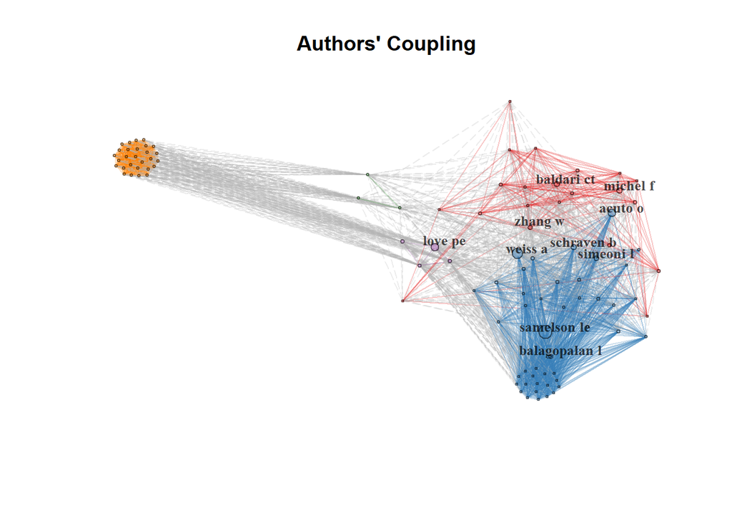

```r
NetMatrix <- biblioNetwork(M, analysis = "coupling", network = "authors", sep = ";")
net=networkPlot(NetMatrix,  normalize = "salton", weighted=NULL, n = 100, Title = "Authors' Coupling", type = "fruchterman", size=5,size.cex=T,remove.multiple=TRUE,labelsize=0.8,label.n=10,label.cex=F)
```

#### Co-citação e colaboração bibliográfica

Dois artigos são co-citados quando ambos são citadas por um mesmo artigo. Como qualquer outra rede, é possível fazer uma para co-citação utilizando-se a função “biblioNetwork”.

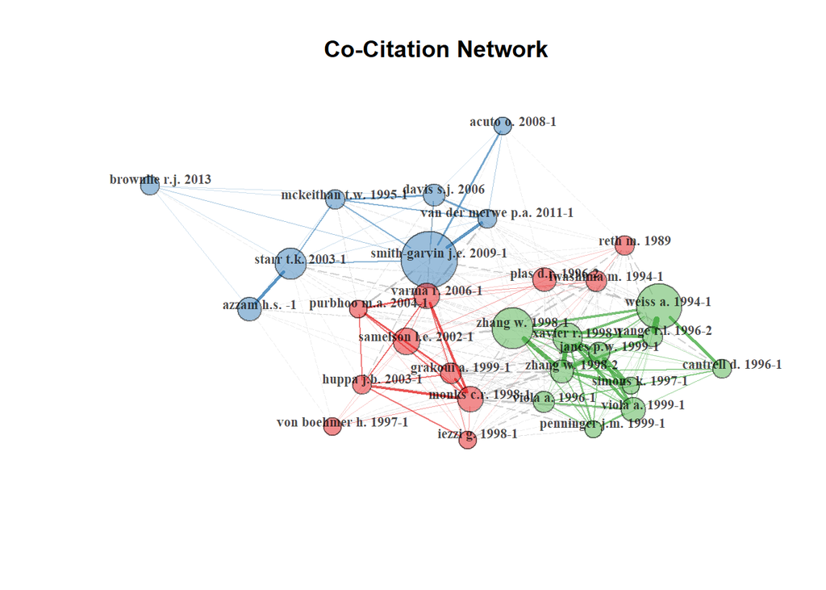

```r
NetMatrix <- biblioNetwork(M, analysis = "co-citation", network = "references", sep = ";")
net=networkPlot(NetMatrix, n = 30, Title = "Co-Citation Network", type = "fruchterman", size=T, remove.multiple=FALSE, labelsize=0.7,edgesize = 5)
```

Em uma rede de colaboração científica os nós são os autores enquanto que os links são as co-autorias de um artigo, pois já se sabe que o segundo é uma das formas mais bem documentadas de colaboração científica entre dois pesquisadores (de acordo com Glanzel, 2004).

Novamente, usando a função “biblioNetwork”, é possível calcular uma rede de colaboração científica por países, por exemplo:

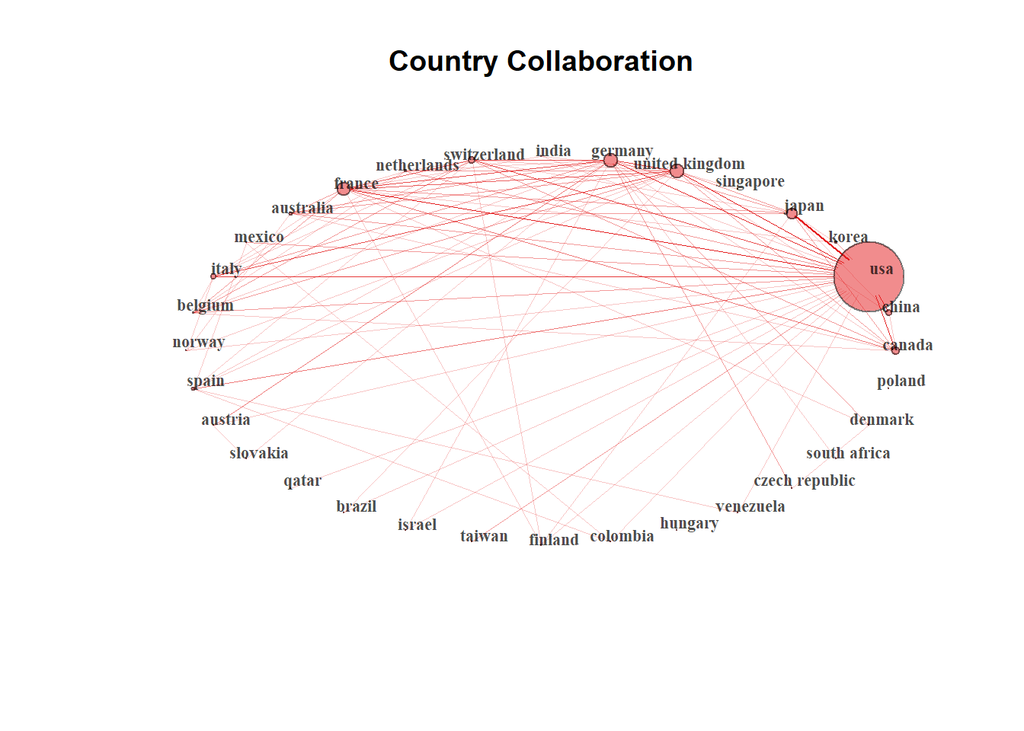

```r
M <- metaTagExtraction(M, Field = "AU_CO", sep = ";")
NetMatrix <- biblioNetwork(M, analysis = "collaboration", network = "countries", sep = ";")
net=networkPlot(NetMatrix, n = dim(NetMatrix)[1], Title = "Country Collaboration", type = "circle", size=TRUE, remove.multiple=FALSE,labelsize=0.7,cluster="none")
```

#### Análise descritiva das características gráficas de redes

A função “networkStat” calcula várias estatísticas das nossas redes de forma resumida. Partindo de uma matriz bibliográfica, dois grupos de medidas descritivas são computadas:

- as estatísticas resumidas de uma rede

```r
NetMatrix <- biblioNetwork(M, analysis = "co-occurrences", network = "keywords", sep = ";")
netstat <- networkStat(NetMatrix)
names(netstat$network)
```

```
##  [1] "networkSize"             "networkDensity"          "networkTransitivity"     "networkDiameter"
##  [5] "networkDegreeDist"       "networkCentrDegree"      "networkCentrCloseness"   "networkCentrEigen"
##  [9] "networkCentrbetweenness" "NetworkAverPathLeng"
```

- e os principais indíces referentes a centralidade e prestígio dos vértices

```r
NetMatrix <- biblioNetwork(M, analysis = "co-occurrences", network = "keywords", sep = ";")
netstat <- networkStat(NetMatrix)
names(netstat$vertex)
```

[output not shown]

```r
summary(netstat, k=10)
```

```
##
##
## Main statistics about the network
##
##  Size                                  3275
##  Density                               0.042
##  Transitivity                          0.198
##  Diameter                              3
##  Degree Centralization                 0.907
##  Average path length                   1.958
##
```

#### Rede histórica de citações diretas

Proposto por E. Garfield em 2004, o mapa historiográfico é um gráfico que representa uma rede cronológica mostrando as citações diretas mais importantes a partir da nossa coleção bibliográfica. Essa mapa é gerado a partir da função “histPlot” após se aplicar a função “histNetwork”, capaz de montar essa rede cronológica de citações diretas.

```r
options(width=130)
histResults <- histNetwork(M, min.citations = 10, sep = ";")
```

```
## Articles analysed   100
## Articles analysed   200
## Articles analysed   300
## Articles analysed   340
```

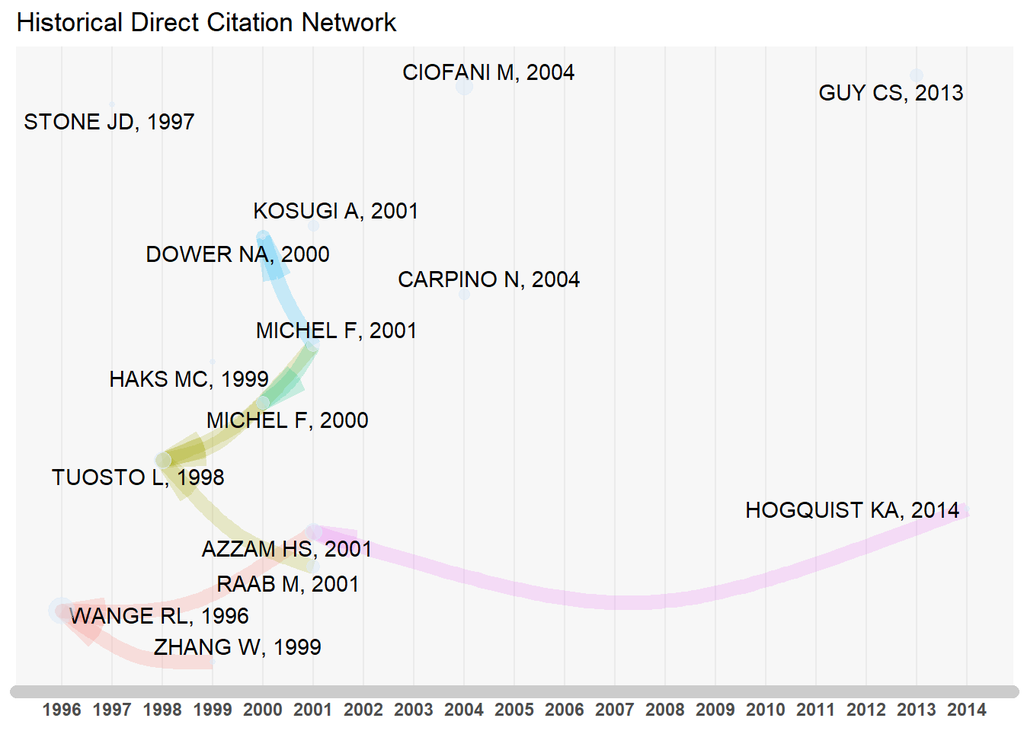

```
##
##  Legend
##
##                                     Paper                                                                DOI Year LCS GCS
## 1996 - 21        WANGE RL, 1996, IMMUNITY                                      10.1016/S1074-7613(00)80315-5 1996  19 443
## 1997 - 33       STONE JD, 1997, J IMMUNOL                                                               <NA> 1997   5  85
## 1998 - 54   TUOSTO L, 1998, EUR J IMMUNOL 10.1002/(SICI)1521-4141(199807)28:07<2131::AID-IMMU2131>3.0.CO;2-Q 1998   9  85
## 1999 - 81      ZHANG W, 1999, INT IMMUNOL                                            10.1093/INTIMM/11.6.943 1999   5 218
## 1999 - 87         HAKS MC, 1999, IMMUNITY                                      10.1016/S1074-7613(00)80084-9 1999   5 104
## 2000 - 91       MICHEL F, 2000, J IMMUNOL                                        10.4049/JIMMUNOL.165.7.3820 2000   7  73
## 2000 - 103    DOWER NA, 2000, NAT IMMUNOL                                                      10.1038/79766 2000   5 334
## 2001 - 115      AZZAM HS, 2001, J IMMUNOL                                        10.4049/JIMMUNOL.166.9.5464 2001   9 180
## 2001 - 121       MICHEL F, 2001, IMMUNITY                                      10.1016/S1074-7613(01)00244-8 2001   7 128
## 2001 - 122         RAAB M, 2001, IMMUNITY                                      10.1016/S1074-7613(01)00248-5 2001   7  84
## 2001 - 127       KOSUGI A, 2001, IMMUNITY                                      10.1016/S1074-7613(01)00146-7 2001   6  85
## 2004 - 173     CIOFANI M, 2004, J IMMUNOL                                        10.4049/JIMMUNOL.172.9.5230 2004   9 183
## 2004 - 176      CARPINO N, 2004, IMMUNITY                                      10.1016/S1074-7613(03)00351-0 2004   6 100
## 2013 - 303      GUY CS, 2013, NAT IMMUNOL                                                    10.1038/NI.2538 2013   7  97
## 2014 - 317 HOGQUIST KA, 2014, NAT IMMUNOL                                                    10.1038/NI.2938 2014   5  91
```

```r
net <- histPlot(histResults, n=15, size = 20, labelsize=10, size.cex=TRUE, arrowsize = 0.5, color = TRUE)
```

## Respostas encontradas

Segue agora uma lista com todas os gráficos e tabelas montados durante o trabalho:

## Dificuldades encontradas

As principais dificuldades foram relativas à algumas características referentes ao próprio Rmarkdown. Enquanto o guia do pacote “Bibliometrix” era muito bom e intuivo, o Rmarkdown teve alguns problemas. O principal deles foi referente ao salvamente (knit) para outros formatos. Mesmo com o software Miktex tendo sido instalado, não houve a mínima possibilidade de se salvar o script em pdf. Além disso, no formato word todos os gráficos e tabelas acabavam ficando desconfigurados em relação ao seu tamanho original e, por causa disso, acabou por se escolher como formato final de visualização o html. Além disso, outra dificuldade foi a em encontrar funções ou formas de se fazer o negrito. itálico e sublinhado no próprio rmarkdown, vide que a página de help dele dentro do próprio RStudio ou mesmo no Cran não detinham tal informação (ou se detinham estavam muito bem escondidas pois o autor desse trabalho e outros cinco alunos foram incapazes de encontrá-la). Outro problema com o próprio Rmarkdown foi a incapacidade de se inserir logo no começo do desenvolvimento as funções install.packages para o pacote do Rmarkdown per se e do Bibliometrics, pois repetidas vezes erros eram dados e o salvamento (knit) era impossibilitado de ser feito. Dito tudo isso, o trabalho foi relativamente fácil de se fazer, garantindo uma confiança muito maior ao autor deste que se acostumou a procurar a ajuda de diversas funções na tentativa de entende-las melhor e aplicar em seus próprios projetos algumas ideas obtidas no decorrer da execução deste.

## Bibliografia

Aria, M. & Cuccurullo, C. (2019). A brief introduction to bibliometrix (https://cran.r-project.org/web/packages/bibliometrix/vignettes/bibliometrix-vignette.html).

Arquivo de Referência do Pacote “rmarkdown” (https://cran.r-project.org/web/packages/rmarkdown/rmarkdown.pdf).

Arquivo de Referência do Pacote “bibliometrix” (https://cran.r-project.org/web/packages/bibliometrix/bibliometrix.pdf).

Aria, M. & Cuccurullo, C. (2017). bibliometrix: An R-tool for comprehensive science mapping analysis, Journal of Informetrics, 11(4), pp 959-975, Elsevier, DOI: 10.1016/j.joi.2017.08.007 (https://doi.org/10.1016/j.joi.2017.08.007).

Cuccurullo, C., Aria, M., & Sarto, F. (2016). Foundations and trends in performance management. A twenty-five years bibliometric analysis in business and public administration domains, Scientometrics, DOI: 10.1007/s11192-016-1948-8 (https://doi.org/10.1007/s11192-016-1948-8).

Cuccurullo, C., Aria, M., & Sarto, F. (2015). Twenty years of research on performance management in business and public administration domains. Presentation at the Correspondence Analysis and Related Methods conference (CARME 2015) in September 2015 (http://www.bibliometrix.org/documents/2015Carme_cuccurulloetal.pdf).

Sarto, F., Cuccurullo, C., & Aria, M. (2014). Exploring healthcare governance literature: systematic review and paths for future research. Mecosan (http://www.francoangeli.it/Riviste/Scheda_Rivista.aspx?IDarticolo=52780&lingua=en).

Cuccurullo, C., Aria, M., & Sarto, F. (2013). Twenty years of research on performance management in business and public administration domains. In Academy of Management Proceedings (Vol. 2013, No. 1, p. 14270). Academy of Management (https://doi.org/10.5465/AMBPP.2013.14270abstract).